# The influence of borrower income on the loans they recieve

## by Naomi Ayibaemi Frank-Opigo

## Investigation Overview

This presentation seeks to highlight the factors that influnce the loan amount borrowers are able to access and trends of loan seeking behaviour.

## Dataset Overview

This dataset contains borrower data and loan data for 113937 loan listings in the USA. There are 113,937 loan entries with 81 details each. The data types include : floats, integers,datetime, categorical, boolean and string. Most variables are numeric. 2 columns were added which indicate the year and quarter the listing was made. They are named "Year" and "Quarter".

## Distribution of Loan amount

The loan amounts vary widely but have a minimum of 1,000 USD and a recorded maximum of 35,000 USD. Generally, fewer borrowers request larger amounts. The loan amount with the highest borrower count is 4,000 USD

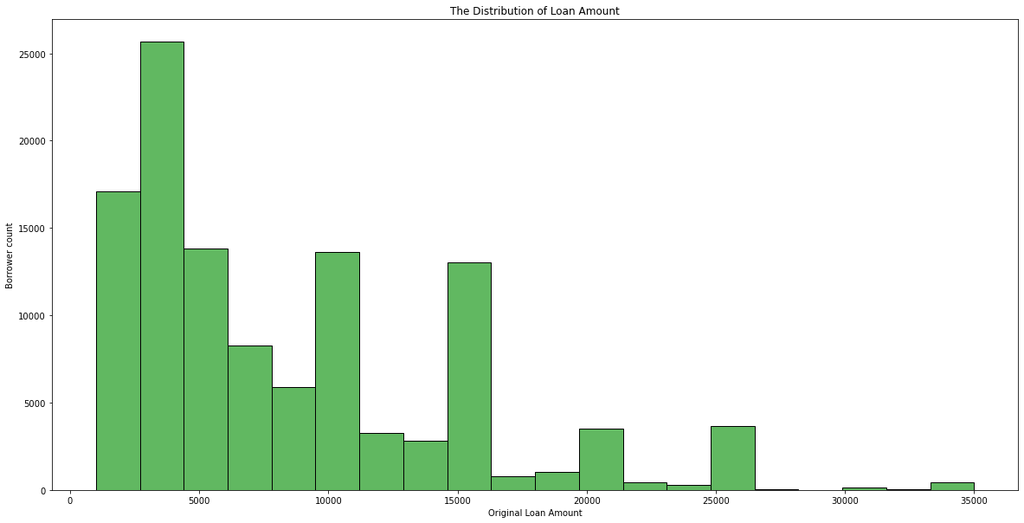

## The relationship between loan amounts,annual interest rate and borrower income range

#### Borrower APR vs Original Loan Amount

The annual interest rates are represented by the Borrower APR which ranges from 0.01 - 0.5. The data shows that borrower APR tends to decrease as the loan amount increases.

#### Original Loan amount vs Borrower income ranges

Higher earning borrowers tend to access loans of higher amounts as opposed to the low earning counterparts. This, therefore, also gives them acces to lower annual interest rates.

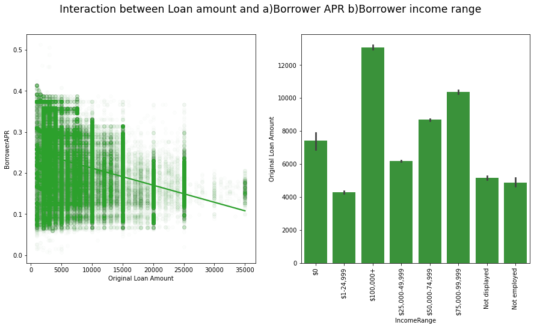

## Number of Loans per year

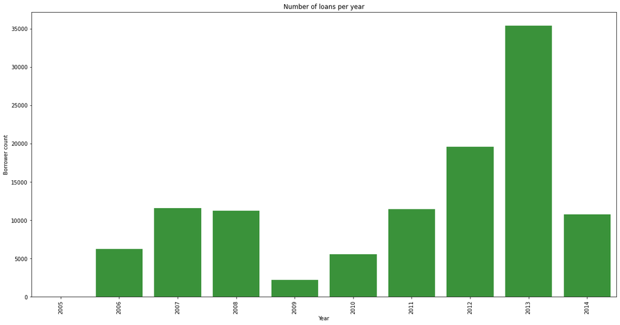

## What state has the highest borrower count?

This dataset covers all 50 states and Washington DC. This allows us see what states contribute more towards the annual borrower count. From the graph it shows that California has the hightest borrower count. Followed in the distance by Texas, New York and Florida.

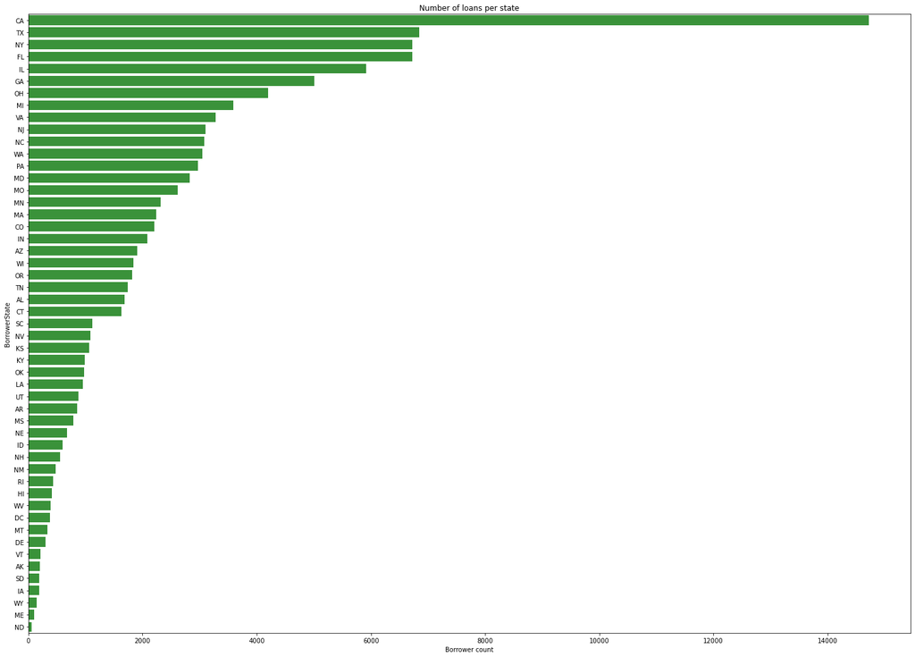